# CDI:WS Production Bias Report

Nathan, George, & Mike

8/17/2021

# Introduction

## Differential Item Function

### Dataset

| Var1 | Freq |
| --- | --- |
| Female | 1989 |
| Male | 2101 |
| Other | 0 |

## Goals

For each axis (sex, SES, race/ethnicity) 1) show GLIMMER plots (small sample of words) 2) histograms of DIF: fit normal distro, exclude >2SD (list those items) - overall statistic measuring DIF of the test? sd(normal), but that doesn’t account for overall group difference (subtract mean?) (DTF definition/statistic) 3) re-fit IRT model, show new GLIMMER (discuss: does the test look much more fair, or are there new outliers?) 4) suggested new words from CHILDES (equal frequency for boys/girls) [but we can’t do this for SES/race unless CHILDES has demo data]

## Sex DIF

### GLIMMER plots

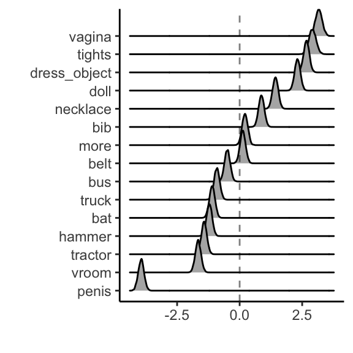

GLIMMER plot for sample of items showing most DIF in both directions, as well as a random sample from the middle.

### Removing Biased Items

Histogram of Sex Items from GLIMMER

```
## [1] "mininum difference: -0.429399432896487 maximum difference: 0.9601645092777"
```

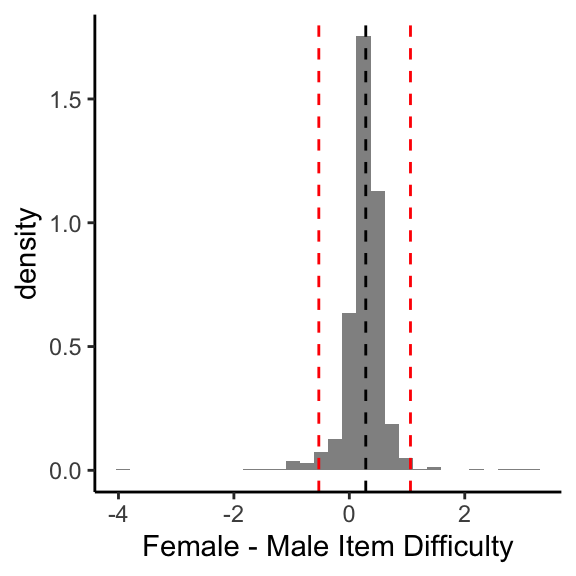

| definition | d_diff | sex_bias |
| --- | --- | --- |
| penis* | -3.94 | Male |
| vroom | -1.66 | Male |
| tractor | -1.42 | Male |
| hammer | -1.21 | Male |
| bat | -1.10 | Male |
| firetruck | -0.94 | Male |
| dump | -0.93 | Male |
| police | -0.91 | Male |
| truck | -0.91 | Male |
| motorcycle | -0.87 | Male |
| fireman | -0.82 | Male |
| lawn mower | -0.78 | Male |
| helicopter | -0.76 | Male |
| ladder | -0.70 | Male |
| hose | -0.65 | Male |
| cowboy | -0.60 | Male |
| give me five! | -0.55 | Male |
| choo choo | -0.53 | Male |
| bus | -0.49 | Male |
| boat | -0.48 | Male |
| shovel | -0.47 | Male |
| gas station | -0.45 | Male |
| train | -0.44 | Male |
| broom | -0.43 | Male |
| baby | 0.97 | Female |
| purse | 1.04 | Female |
| underpants | 1.16 | Female |
| pretty | 1.39 | Female |
| necklace | 1.43 | Female |
| doll | 2.31 | Female |
| dress (object) | 2.67 | Female |
| tights | 2.91 | Female |
| vagina* | 3.17 | Female |

List of Sex Items that show DIF outside of the 2SD range.(shows 33 items that have DIF)

see what the new distribution of item difficulty differences looks like (are there any more outliers?)

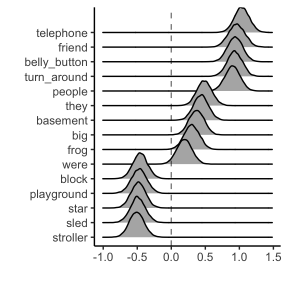

GLIMMER plot for sample of items showing most DIF in both directions, as well as a random sample from the middle.

Sex Histogram with the DIF Items removed

```
## [1] "mininum difference: -0.202378778935467 maximum difference: 0.738317279471875"
```

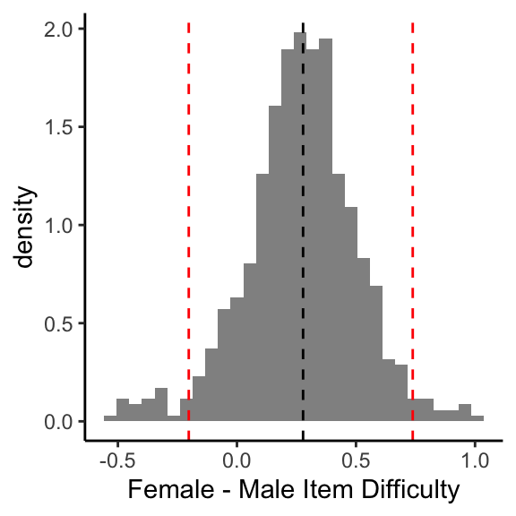

| definition | d_diff | sex_bias |
| --- | --- | --- |
| bus | -0.51 | Male |
| boat | -0.49 | Male |
| shovel | -0.48 | Male |
| gas station | -0.47 | Male |
| train | -0.46 | Male |
| broom | -0.44 | Male |
| sprinkler | -0.40 | Male |
| nail | -0.40 | Male |
| garage | -0.39 | Male |
| moose | -0.37 | Male |
| tricycle | -0.37 | Male |
| vacuum | -0.36 | Male |
| build | -0.35 | Male |
| mop | -0.34 | Male |
| grrr | -0.34 | Male |
| mailman | -0.33 | Male |
| roof | -0.33 | Male |
| throw | -0.30 | Male |
| jeans | -0.24 | Male |
| stick | -0.23 | Male |
| bicycle | -0.21 | Male |
| bunny | 0.74 | Female |
| happy | 0.78 | Female |
| stroller | 0.79 | Female |
| potty | 0.79 | Female |
| belly button | 0.80 | Female |
| she | 0.85 | Female |
| bib | 0.86 | Female |
| beads | 0.88 | Female |
| girl | 0.90 | Female |
| pattycake | 0.93 | Female |
| sweater | 0.94 | Female |
| baby | 0.96 | Female |
| purse | 1.04 | Female |

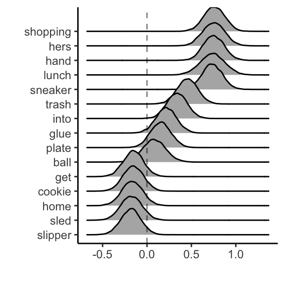

GLIMMER plot for sample of items showing most DIF in both directions, as well as a random sample from the middle.

Sex Histogram with the DIF Items removed

```
## [1] "mininum difference: -0.0861092774554755 maximum difference: 0.680257567183039"
```

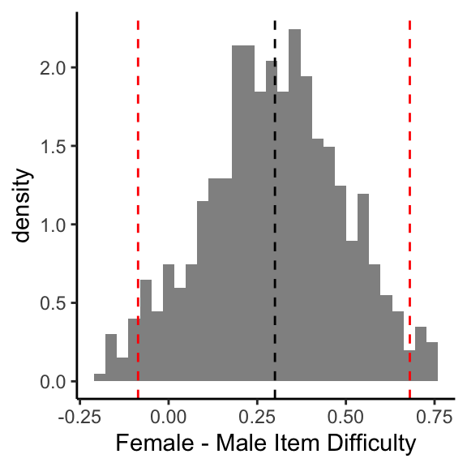

| definition | d_diff | sex_bias |
| --- | --- | --- |
| shorts | -0.18 | Male |
| car | -0.17 | Male |
| farm | -0.16 | Male |
| coke | -0.15 | Male |
| fix | -0.15 | Male |
| airplane | -0.15 | Male |
| flag | -0.15 | Male |
| hit | -0.14 | Male |
| fast | -0.13 | Male |
| knock | -0.12 | Male |
| backyard | -0.11 | Male |
| skate | -0.10 | Male |
| blue | -0.10 | Male |
| kick | -0.10 | Male |
| catch | -0.10 | Male |
| kitty | 0.69 | Female |
| tissue/kleenex | 0.69 | Female |
| buttocks/bottom* | 0.70 | Female |
| lamb | 0.70 | Female |
| teddybear | 0.70 | Female |
| me | 0.70 | Female |
| dish | 0.72 | Female |
| cute | 0.72 | Female |
| hers | 0.73 | Female |
| slipper | 0.73 | Female |
| hi | 0.74 | Female |
| her | 0.75 | Female |
| hair | 0.75 | Female |
| shh/shush/hush | 0.76 | Female |

29 item that now show DIF

## SES DIF

| Var1 | Freq |
| --- | --- |
| high | 3544 |
| low | 546 |

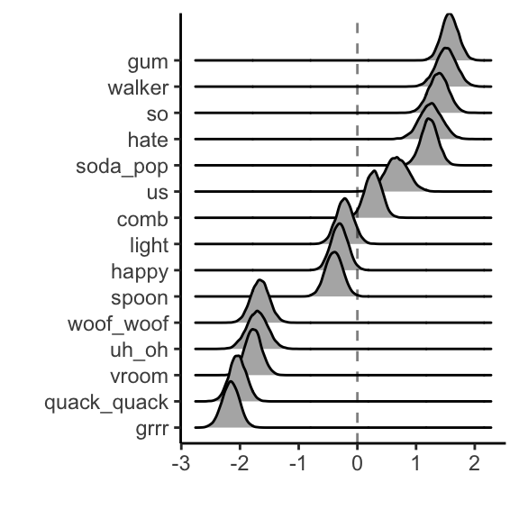

GLIMMER plot for sample of items showing most DIF in both directions, as well as a random sample from the middle.

Histogram from SES GLIMMER

```
## [1] "mininum difference: -0.84601536585325 maximum difference: 0.94863882075585"
```

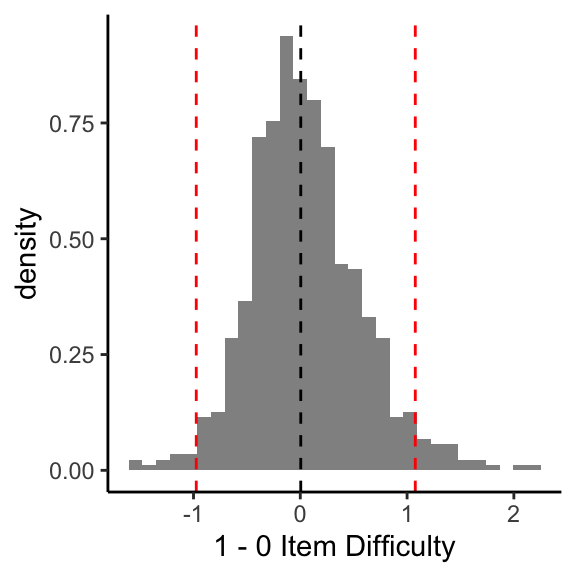

| definition | d_diff | ses_bias |
| --- | --- | --- |
| gum | -1.58 | Low |
| walker | -1.51 | Low |
| so | -1.38 | Low |
| hate | -1.25 | Low |
| soda/pop | -1.23 | Low |
| each | -1.13 | Low |
| candy | -1.12 | Low |
| why | -1.10 | Low |
| can (object) | -1.06 | Low |
| but | -1.01 | Low |
| penny | -1.00 | Low |
| radio | -0.94 | Low |
| would | -0.93 | Low |
| bad | -0.91 | Low |
| donut | -0.90 | Low |
| brother | -0.88 | Low |
| mad | -0.88 | Low |
| give me five! | -0.88 | Low |
| hamburger | -0.88 | Low |
| be | -0.85 | Low |
| if | -0.85 | Low |
| cracker | 0.96 | High |
| moon | 0.97 | High |
| turtle | 0.97 | High |
| down | 0.97 | High |
| blue | 0.97 | High |
| more | 0.98 | High |
| bye | 1.00 | High |
| yogurt | 1.00 | High |
| lion | 1.03 | High |
| elephant | 1.08 | High |
| all gone | 1.09 | High |
| bear | 1.09 | High |
| block | 1.11 | High |
| choo choo | 1.15 | High |
| zebra | 1.15 | High |
| owl | 1.17 | High |
| gentle | 1.19 | High |
| mommy* | 1.22 | High |
| sheep | 1.23 | High |
| meow | 1.24 | High |
| pet’s name | 1.26 | High |
| up | 1.31 | High |
| baa baa | 1.31 | High |
| yum yum | 1.37 | High |
| giraffe | 1.37 | High |
| babysitter’s name | 1.38 | High |
| daddy* | 1.39 | High |
| cockadoodledoo | 1.39 | High |
| moo | 1.52 | High |
| duck | 1.55 | High |
| woof woof | 1.66 | High |
| uh oh | 1.70 | High |
| vroom | 1.77 | High |
| quack quack | 2.04 | High |
| grrr | 2.15 | High |

List of SES Items that show DIF outside of the 2SD range. (56 items that show DIF)

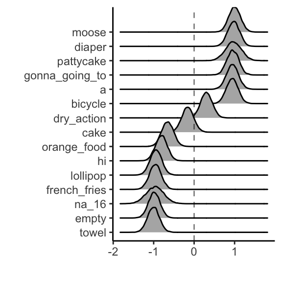

GLIMMER plot for sample of items showing most DIF in both directions, as well as a random sample from the middle.

New Histogram with the DIF Items removed

```
## [1] "mininum difference: -0.768888551399873 maximum difference: 0.714849064048322"
```

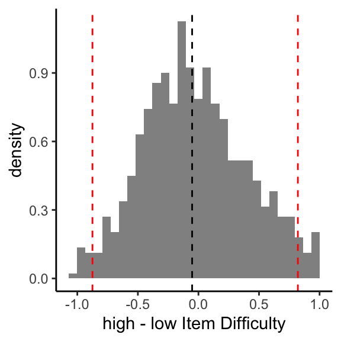

| definition | d_diff | ses_bias |
| --- | --- | --- |
| radio | -1.00 | Low |
| bad | -0.99 | Low |
| would | -0.97 | Low |
| donut | -0.96 | Low |
| hamburger | -0.95 | Low |
| give me five! | -0.94 | Low |
| brother | -0.94 | Low |
| mad | -0.93 | Low |
| be | -0.90 | Low |
| mop | -0.88 | Low |
| if | -0.88 | Low |
| by | -0.87 | Low |
| love | -0.86 | Low |
| an | -0.86 | Low |
| salt | -0.85 | Low |
| write | -0.82 | Low |
| sister | -0.81 | Low |
| could | -0.79 | Low |
| money | -0.78 | Low |
| potato chip | -0.77 | Low |
| rip | -0.77 | Low |
| penguin | 0.72 | High |
| red | 0.72 | High |
| hi | 0.72 | High |
| cheerios | 0.72 | High |
| banana | 0.73 | High |
| knee | 0.74 | High |
| bird | 0.74 | High |
| rooster | 0.75 | High |
| tractor | 0.75 | High |
| bubbles | 0.75 | High |
| star | 0.75 | High |
| belly button | 0.75 | High |
| grandpa* | 0.76 | High |
| glasses | 0.76 | High |
| yellow | 0.77 | High |
| green | 0.79 | High |
| bunny | 0.80 | High |
| clock | 0.80 | High |
| pretzel | 0.80 | High |
| butterfly | 0.80 | High |
| frog | 0.81 | High |
| peas | 0.81 | High |
| garage | 0.82 | High |
| play dough | 0.86 | High |
| button | 0.87 | High |
| book | 0.90 | High |
| bib | 0.90 | High |
| cow | 0.90 | High |
| alligator | 0.91 | High |
| cracker | 0.93 | High |
| turtle | 0.94 | High |
| moon | 0.94 | High |
| blue | 0.94 | High |
| down | 0.95 | High |
| more | 0.95 | High |
| bye | 0.97 | High |
| yogurt | 0.98 | High |
| lion | 1.00 | High |

## Race/Ethnicity DIF

Race is not a stand alone factor; people of each race fall into every combination of the other axes we have analyzed. Perhaps whiteness and SES are highly correlated in our data. Any binerized set of data will have members of each group that are different across another axis. It will perhap be worth while to specify even further such as the effect of white vs. non-white but only amongst high SES kids.

| Var1 | Freq |
| --- | --- |
| Nonwhite | 513 |
| White | 2199 |

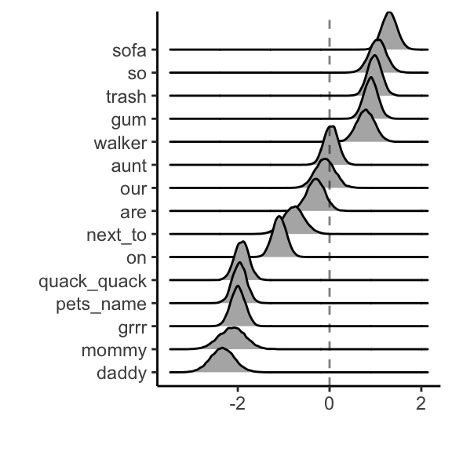

GLIMMER plot for sample of items showing most DIF in both directions, as well as a random sample from the middle.

Histogram from ETH GLIMMER

```
## [1] "mininum difference: -0.506363077574259 maximum difference: 1.42088642031681"
```

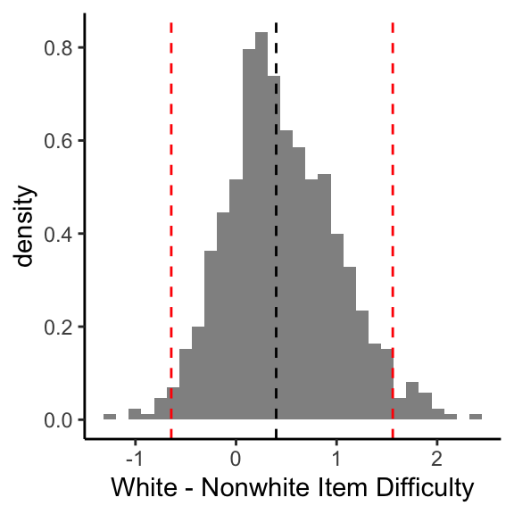

| definition | d_diff | ses_bias |
| --- | --- | --- |
| sofa | -1.30 | Non-White |
| so | -1.05 | Non-White |
| trash | -0.98 | Non-White |
| gum | -0.90 | Non-White |
| walker | -0.79 | Non-White |
| wish | -0.74 | Non-White |
| give me five! | -0.73 | Non-White |
| finish | -0.69 | Non-White |
| candy | -0.69 | Non-White |
| if | -0.69 | Non-White |
| coke | -0.66 | Non-White |
| brother | -0.64 | Non-White |
| child | -0.58 | Non-White |
| tonight | -0.57 | Non-White |
| radio | -0.55 | Non-White |
| face | -0.54 | Non-White |
| wait | -0.54 | Non-White |
| bathroom | -0.51 | Non-White |
| no | 1.43 | White |
| moon | 1.43 | White |
| meow | 1.45 | White |
| bunny | 1.46 | White |
| belly button | 1.47 | White |
| mittens | 1.47 | White |
| yellow | 1.48 | White |
| swing (object) | 1.49 | White |
| lawn mower | 1.50 | White |
| cracker | 1.50 | White |
| baa baa | 1.51 | White |
| snow | 1.52 | White |
| shovel | 1.53 | White |
| sheep | 1.54 | White |
| owie/boo boo | 1.56 | White |
| down | 1.60 | White |
| duck | 1.61 | White |
| bib | 1.64 | White |
| owl | 1.65 | White |
| vroom | 1.71 | White |
| kitty | 1.72 | White |
| boat | 1.73 | White |
| peas | 1.74 | White |
| tractor | 1.76 | White |
| button | 1.77 | White |
| up | 1.79 | White |
| moo | 1.82 | White |
| bye | 1.85 | White |
| uh oh | 1.87 | White |
| all gone | 1.91 | White |
| quack quack | 1.92 | White |
| pet’s name | 1.97 | White |
| grrr | 2.00 | White |
| mommy* | 2.12 | White |
| daddy* | 2.34 | White |

List of Eth Items that show DIF outside of the 2SD range. (53 that show DIF)

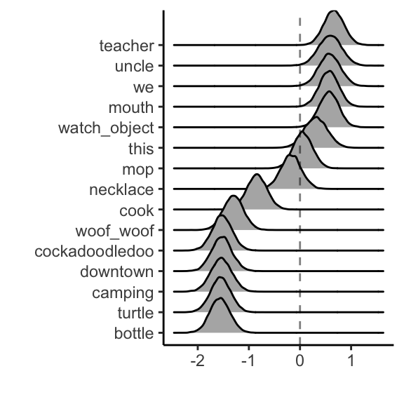

GLIMMER plot for sample of items showing most DIF in both directions, as well as a random sample from the middle.

New Histogram with the DIF Items removed

```
## [1] "mininum difference: -0.419305243846048 maximum difference: 1.27663140112282"
```

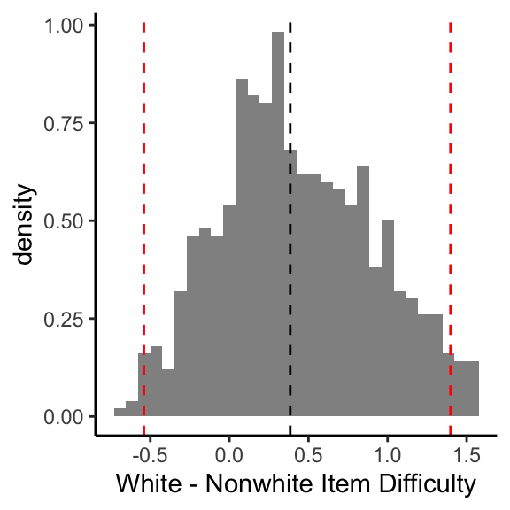

| definition | d_diff | eth_bias |
| --- | --- | --- |
| brother | -0.66 | Non-White |
| child | -0.59 | Non-White |
| tonight | -0.58 | Non-White |
| radio | -0.57 | Non-White |
| face | -0.57 | Non-White |
| wait | -0.56 | Non-White |
| bathroom | -0.54 | Non-White |
| write | -0.51 | Non-White |
| police | -0.51 | Non-White |
| salt | -0.51 | Non-White |
| but | -0.51 | Non-White |
| can (object) | -0.49 | Non-White |
| food | -0.49 | Non-White |
| school | -0.48 | Non-White |
| jacket | -0.48 | Non-White |
| listen | -0.47 | Non-White |
| stop | -0.46 | Non-White |
| lips | -0.46 | Non-White |
| buy | -0.45 | Non-White |
| mop | -0.44 | Non-White |
| smile | -0.42 | Non-White |
| why | -0.42 | Non-White |
| toast | 1.29 | White |
| squirrel | 1.30 | White |
| cockadoodledoo | 1.30 | White |
| blue | 1.31 | White |
| sandbox | 1.31 | White |
| woof woof | 1.32 | White |
| yucky | 1.32 | White |
| swing (action) | 1.33 | White |
| more | 1.34 | White |
| green | 1.34 | White |
| hot | 1.36 | White |
| block | 1.37 | White |
| cow | 1.38 | White |
| yogurt | 1.40 | White |
| babysitter’s name | 1.40 | White |
| bird | 1.42 | White |
| outside | 1.42 | White |
| no | 1.42 | White |
| moon | 1.44 | White |
| meow | 1.46 | White |
| bunny | 1.46 | White |
| mittens | 1.48 | White |
| belly button | 1.48 | White |
| yellow | 1.48 | White |
| swing (object) | 1.50 | White |
| lawn mower | 1.51 | White |
| cracker | 1.51 | White |
| baa baa | 1.52 | White |
| snow | 1.53 | White |
| shovel | 1.54 | White |
| sheep | 1.55 | White |
| owie/boo boo | 1.57 | White |

# Discussion

Where to go from here – other languages, regional variation, - using adult word vectors to find unbiased items?